# single-cell nano CUT&Tag - Downstream Analysis Tutorial

Federico Ansaloni

Karolinska Institutet

Compiled: March 11, 2023

## What is this tutorial for?

This tutorial describes how to perform the dowstream analysis on single-cell nano CUT&Tag data.

This tutorial assumes that the data have already been preprocessed, including demultiplexing of the different modalities, running cellranger and custom cell calling (see [Set Up](https://github.com/bartosovic-lab/single-cell-nano-cut-tag#set-up) and [Preprocessing](https://github.com/bartosovic-lab/single-cell-nano-cut-tag#preprocessing)).

The input files needed at this stage are (for each modality, for each sample):  
1. `fragments.tsv.gz` and its index `fragments.tsv.gz.tbi`  
2. `metadata.csv`  
3. `peaks.broadPeak`

You can find a toy example (2 samples, 3 modalities) [here](https://github.com/bartosovic-lab/single-cell-nano-cut-tag)

**1. Data loading (peaks, metadata and fragments)**  
**2. Quality controls (QC)**  
**3. Merge Seurat objects**  
**4. Normalisation and dimensional reduction**  
**5. Non-linear dimension reduction and clustering**  
**6. Integration with scRNA-seq dataset**  
**7. Cluster annotation**

## 1. Data loading (peaks, metadata and fragments)

In this section we are going to load the input files for each modality and sample, create a common set of peaks for each sample, create a fragment object for each experiment, generate a peaks x cell matrix for each experiment and finally generate one Seurat object for experiment.

- Inputs of this section are the `fragments.tsv.gz`, `metadata.csv` and `peaks.broadPeak` files.
- Output of his section is a Seurat object for each experiment (6 in this case [2 samples * 3 modalities]).

### Setting some initial variables

First, define some variables that will be used across the entire vignette. Modify them according to your data.  
**Extremely important is that you set as `wd` the directory where the Github repo was previously downloaded. This is required in order to upload all the custom functions needed to run this vignette.**

```r
# directory where the single-cell-nano-cut-tag repo was cloned
wd <- "/Users/federico/Dropbox/KI/marek/repo/" # change accordingly
source(paste0(wd,"single-cell-nano-cut-tag/scripts/functions_scCT.R"))
# Set the used genome version
genome <- "mm10"
# Assay (peaks or bins)
assay <- "peaks"
# Samples
samples <- c("bcdCT_MB21_02","bcdCT_MB21_04")
# Modalities
modalities <- c("ATAC_TATAGCCT","H3K27ac_ATAGAGGC","H3K27me3_CCTATCCT")
# Minimum number of cells a feature must be detected in to be included in the Seurat obj
min_cell <- 1
# Minium number of features a cell must have to be included in the Seurat obj
min_feat <- 1
```

### Loading peaks from different modalities and samples

Here we are going to load the peaks data for each modality, for each sample.  
For convenience, each file will be stored in a list.

```r
# Read-in peak coordinates for each modality iterating across samples and modalities
input.ls <- list()
for (smpl in samples) {
  cat("Loading peaks for sample",smpl,"\n")
  for (mod in modalities) {
    cat("\t",mod,"\n")

    # get mod name withouth barcode
    mod2 <- strsplit(mod,"_")[[1]][1]

    # Load peak files
    input.ls[[paste0(mod,"_",smpl)]] <- read.table(paste0(smpl,"/",mod,"/peaks/macs_broad/",mod2,"_peaks.broadPeak"))[1:3]
    colnames(input.ls[[paste0(mod,"_",smpl)]] ) <- c("chr", "start", "end")

  }
}
```

```
## Loading peaks for sample bcdCT_MB21_02
##   ATAC_TATAGCCT
##   H3K27ac_ATAGAGGC
##   H3K27me3_CCTATCCT
## Loading peaks for sample bcdCT_MB21_04
##   ATAC_TATAGCCT
##   H3K27ac_ATAGAGGC
##   H3K27me3_CCTATCCT
```

### Creating a common set of peaks

Since the peaks were identified independently in each experiment and modality, it is unlikely they will perfectly overlap. We thus need to merge the peaks from the different samples and modalities in analysis in order to create a common peak set, and quantify this peak set in each experiment prior to merging the objects.

This will be done by following the [Signac vignette](https://stuartlab.org/signac/articles/merging.html).

First, convert peaks to genomic ranges

```r
input.ls <- lapply(input.ls,function(x){ makeGRangesFromDataFrame(x) })
```

(*We are going to frequently use the `lapply` function. `lapply` applies a given R function to all the items (x) of a given list*)

Then, create a common set of peaks among all the samples and modalities. This way it is safe to merge objects from different samples into a single Seurat object (see below **Merge Seurat objects**)

```r
combined.peaks <- reduce(x = c(input.ls[[paste0(modalities[1],"_",samples[1])]],
                               input.ls[[paste0(modalities[2],"_",samples[1])]],
                               input.ls[[paste0(modalities[3],"_",samples[1])]],
                               input.ls[[paste0(modalities[1],"_",samples[2])]],
                               input.ls[[paste0(modalities[2],"_",samples[2])]],
                               input.ls[[paste0(modalities[3],"_",samples[2])]]) )
```

The `combined.peaks` list contains one set of peaks which is common among modalities and samples:

```r
combined.peaks
```

```
## GRanges object with 68110 ranges and 0 metadata columns:
##             seqnames          ranges strand
##                <Rle>       <IRanges>  <Rle>
##       [1]       chr1 3210615-3213108      *
##       [2]       chr1 3361152-3362524      *
##       [3]       chr1 3667086-3678017      *
##       [4]       chr1 4412147-4416971      *
##       [5]       chr1 4425744-4431988      *
##       ...        ...             ...    ...
##   [68106] JH584304.1       491-44360      *
##   [68107] JH584304.1     48370-61344      *
##   [68108] JH584304.1    68562-114400      *
##   [68109] GL456350.1   220860-227838      *
##   [68110] JH584292.1     13043-14058      *
##   -------
##   seqinfo: 42 sequences from an unspecified genome; no seqlengths
```

### Creating fragment objects

To quantify our combined set of peaks in each modality and sample, we need to create a fragment object for each experiment (*i.e.*, an object holding all the information related to a single fragment file). To this end we will use the Signac function `CreateFragmentObject` which requires, for each experiment, the `fragments.tsv.gz` and the `metadata.csv` files.

Let’s start by loading the metadata data!

#### Load metadata files

```r
##### Metadata
# Load metadata for each experiment iterating across the sample list
metadata.ls <- list()
for (smpl in samples) {
  cat("Loading peaks for sample",smpl,"\n")
  for (mod in modalities) {
    cat("\t",mod,"\n")

    # Load metadata
    metadata.ls[[paste0(mod,"_",smpl)]] <- read.csv(paste0(smpl,"/",mod,"/cell_picking/metadata.csv"),
                                                  stringsAsFactors = FALSE)
    rownames(metadata.ls[[paste0(mod,"_",smpl)]]) <- metadata.ls[[paste0(mod,"_",smpl)]]$barcode

 }
}
```

```
## Loading peaks for sample bcdCT_MB21_02
##   ATAC_TATAGCCT
##   H3K27ac_ATAGAGGC
##   H3K27me3_CCTATCCT
## Loading peaks for sample bcdCT_MB21_04
##   ATAC_TATAGCCT
##   H3K27ac_ATAGAGGC
##   H3K27me3_CCTATCCT
```

Then, we select only the cells that have passed internal filtering

```r
# Filter the metadata, selecting only cells that have passed internal filtering ("passed_MB")
metadata.ls <- lapply(metadata.ls, function(x){x[x$passedMB,]})
```

#### Load fragments files and creation of fragment objects

Having loaded the metadta files, we can now create the fragment objects for each experiment.  
As explained in the [Signac vignette](https://stuartlab.org/signac/articles/merging.html), the `CreateFragmentObject` function checks that the file is present on disk, it is compressed and indexed, computes the MD5 sum for the file and the tabix index so that we can tell if the file is modified at any point, and checks that the expected cells (`metadata.csv`) are present in the file.

```r
##### Fragments
# Create one fragment object per each experiment iterating across the sample list
fragment.ls <- list()
for (smpl in samples) {
  cat("Loading peaks for sample",smpl,"\n")
  for (mod in modalities) {
    cat("\t",mod,"\n")

    # Load fragments
    fragment.ls[[paste0(mod,"_",smpl)]] <- CreateFragmentObject(
                                              path = paste0(smpl,"/",mod,"/fragments/fragments.tsv.gz"),
                                              cells = metadata.ls[[paste0(mod,"_",smpl)]]$barcode)

  }
}
```

```
## Loading peaks for sample bcdCT_MB21_02
##   ATAC_TATAGCCT
##   H3K27ac_ATAGAGGC
##   H3K27me3_CCTATCCT
## Loading peaks for sample bcdCT_MB21_04
##   ATAC_TATAGCCT
##   H3K27ac_ATAGAGGC
##   H3K27me3_CCTATCCT
```

```r
head(fragment.ls[[paste0("ATAC_TATAGCCT_",samples[1])]])
```

| chrom | start | end | barcode | readCount |
| --- | --- | --- | --- | --- |
| chr1 | 3003932 | 3004576 | bcdCT_MB21_02_GCCTAGGCAGTTACAC-1 | 1 |
| chr1 | 3003985 | 3004021 | bcdCT_MB21_02_CTACTTAAGTTCAGGG-1 | 7 |
| chr1 | 3005376 | 3005689 | bcdCT_MB21_02_CCAGATACAGCGTCGT-1 | 3 |
| chr1 | 3005764 | 3005913 | bcdCT_MB21_02_CAAGCTAGTTTGCATG-1 | 1 |
| chr1 | 3005861 | 3006012 | bcdCT_MB21_02_TCTCTGGTCCAGAGAG-1 | 1 |
| chr1 | 3006223 | 3006256 | bcdCT_MB21_02_AACAGTCCATCTGCAA-1 | 3 |

### Quantifying peaks in each experiment

Now that each experiment has been associated to a fragment object containing fragments and metadata, we can now create a peaks x cell matrix for each experiment. This will be done by using the Signac function `FeatureMatrix`.  
`FeatureMatrix` basically constructs a peaks x cell matrix by parsing: i) fragments, ii) peaks and iii) metadata. Please, note how the `features` here used to build the peaks x cell matrix are the common set of peaks among modalities and samples identified in the previous step (**Creating a common set of peaks**).

To speed-up the process, we launch `FeatureMatrix` with `process_n = 20000`. This runs OK on our 64GB MacBook Pro, but could go out-of-memory on other systems. If this happens, please, decrease the `process_n` value (2000 should be fine for every system).

```r
# As usual, append the object to a list
counts.ls <- list()
# Iterate among the experiment names in order to retrieve fragments and cell barcodes from the same experiment
for (experim in names(fragment.ls)) {

  # Create FeatureMatrix
  counts.ls[[experim]] <- FeatureMatrix(fragments = fragment.ls[[experim]],           # fragments
                                        features = combined.peaks,                    # common set of peaks
                                        cells = metadata.ls[[experim]]$barcode,       # metadata
                                        process_n = 20000) # the higher, the faster, the more memory is used

}
```

```r
counts.ls[[paste0("ATAC_TATAGCCT_",samples[1])]][1:10,1:25]
```

```
## 10 x 25 sparse Matrix of class "dgCMatrix"
##
## chr1-3210615-3213108 . . . . . . . . . . . . . . . . . . . . . . . . .
## chr1-3361152-3362524 . . . . . . . . . . . . . . . . . . . . . . . . .
## chr1-3667086-3678017 . . . . . 3 . . . . . . . . . . . . . . . . 2 . .
## chr1-4412147-4416971 . . . . . . . 1 . . . . . . . . . . . . . . . . .
## chr1-4425744-4431988 . . . . . . . . . . . . . . . . . . . 1 . . 1 . .
## chr1-4450989-4457167 . . . . . . . . . . . . . . . . . . . . . . 1 . .
## chr1-4468196-4471971 . . . . . . . . . . . . . . . . . . . . . . 1 . .
## chr1-4479753-4480913 . . . . . . . . . . . . . . . . . . . . . . . . .
## chr1-4487290-4509495 . . . . . 2 . 2 . . . . . . . 1 . . 1 2 . . 1 . .
## chr1-4514289-4515435 . . . . . . . . . . . . . . . . . . . . . . . . .
```

### Create one Seurat object for each experiment

Now that we have generated a peaks x cell matrix for each experiment, we can store it in a Seurat object along with the fragment object and the metadata.

This is done for each experiment separately, objects will be merged in the next step. The reason for this is that we would like to first perform QC on each experiment individually and then merge all the experiments in a single Seurat object.

```r
obj.ls <- list()
# Iterate among the experiment names in order to retrieve fragments and cell barcodes from the same experiment
for (experim in names(counts.ls)) {

  # Get sample and modality name from the experiment variable
  smpl <- str_split_fixed(experim,"_",2)[,2]
  modality <- str_split_fixed(experim,"_",2)[,1]

  # Create the chromatin assay
  chrom.assay <- CreateChromatinAssay(counts = counts.ls[[experim]],
                                      fragments = fragment.ls[[experim]],
                                      genome = genome,
                                      min.cells = min_cell,
                                      min.features = min_feat)

  # Create the object
  obj.ls[[experim]] <- CreateSeuratObject(counts = chrom.assay,
                                          assay = assay,
                                          meta.data=metadata.ls[[experim]],
                                          project = smpl)

  # Add some metadata of origin
  obj.ls[[experim]]$dataset <- experim
  obj.ls[[experim]]$modality <- modality

}
```

## 2. Quality controls (QC)

Please note how we are not here applying any filtering on the TSS enrichment score as while this might be relevant for ATAC it is probably not for H3K27ac and H3K27me3. In case, however, you would like to apply this filtering we recommend to follow [Signac’s tutorial](https://stuartlab.org/signac/articles/pbmc_vignette.html#computing-qc-metrics) on this.

- Input of this section is a Seurat object for each experiment (6 in this case [2 samples * 3 modalities]).
- Output of this section is a Seurat object for each experiment (6 in this case [2 samples * 3 modalities]) containing cells which have passed QCs.

```r
obj.ls.qc <- list()
for (experiment in names(obj.ls)) {

  # Calculate 5th and 95th quantiles for logUMI
  logUMI_cutoff_high <- quantile(obj.ls[[experiment]]$logUMI, 0.95)
  logUMI_cutoff_low  <- quantile(obj.ls[[experiment]]$logUMI, 0.05)
  # Calculate 5th quantile for logUMI for % fragments in peaks (here indicated by peak_ratio_MB)
  peak_ratio_MB_cutoff_low  <- quantile(obj.ls[[experiment]]$peak_ratio_MB, 0.05)

  # Filter out cells outside these thresholds
  obj.ls.qc[[experiment]] <- subset(obj.ls[[experiment]],
                                    logUMI > logUMI_cutoff_low &
                                      logUMI < logUMI_cutoff_high &
                                      peak_ratio_MB > peak_ratio_MB_cutoff_low)

  # print number of discarded cells
  old_n_cell <- nrow(obj.ls[[experiment]][[]])
  new_n_cell <- nrow(obj.ls.qc[[experiment]][[]])
  discarded <- old_n_cell - new_n_cell
  cat(experiment,"\n")
  cat("\tdiscarded",discarded,"cells (",round(discarded/old_n_cell*100,2),"%)\n")
}
```

```
## ATAC_TATAGCCT_bcdCT_MB21_02
##  discarded 363 cells ( 13.46 %)
## H3K27ac_ATAGAGGC_bcdCT_MB21_02
##  discarded 379 cells ( 14.25 %)
## H3K27me3_CCTATCCT_bcdCT_MB21_02
##  discarded 351 cells ( 13.04 %)
## ATAC_TATAGCCT_bcdCT_MB21_04
##  discarded 380 cells ( 13.49 %)
## H3K27ac_ATAGAGGC_bcdCT_MB21_04
##  discarded 399 cells ( 14.1 %)
## H3K27me3_CCTATCCT_bcdCT_MB21_04
##  discarded 379 cells ( 13.42 %)
```

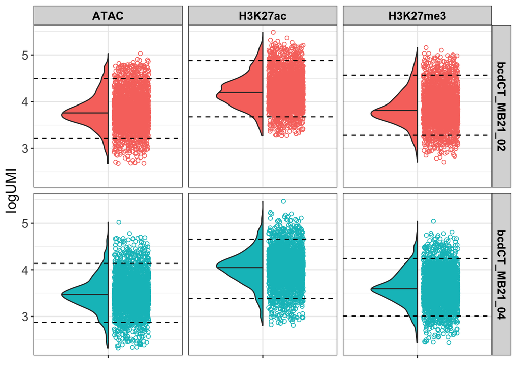

```r
plotUMIcounts(obj = obj.ls, quantiles = c(.05,.95), feature = "logUMI")
```

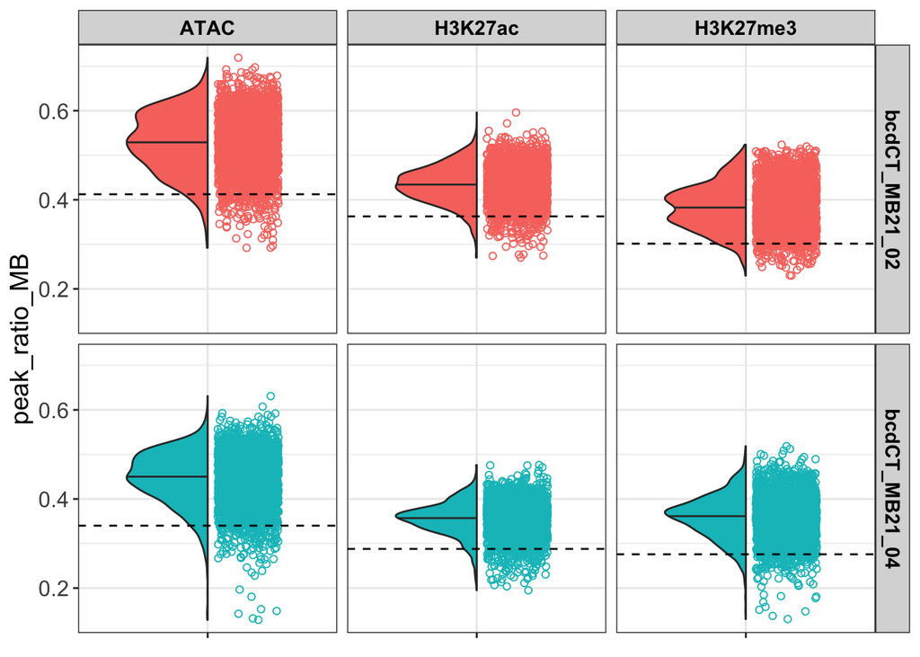

```r
plotUMIcounts(obj = obj.ls, quantiles = c(.05), feature = "peak_ratio_MB")
```

```r
rm(obj.ls)
```

## 3. Merge Seurat objects

Now that we have one object for experiment containing only QC-passed cells, and that all the experiments share a common set of peaks, we can merge all the objects from different samples obtaining one Seurat object for modality.

- Input of this section is a QC-passed Seurat object for each experiment (6 in this case [2 samples * 3 modalities]).
- Output of this section is a single Seurat object for each modality.

### Merge Seurat objects across different samples

```r
combined.obj.ls <- list()
for (mod in modalities) {

  # merge objects among the different samples
  combined.obj.ls[[mod]] <- merge(obj.ls.qc[[paste0(mod,"_",samples[1])]],
                                  y = obj.ls.qc[[paste0(mod,"_",samples[2])]],
                                  add.cell.ids = c(samples[1], samples[2]) )

}
```

```r
combined.obj.ls[["ATAC_TATAGCCT"]][["peaks"]]
```

```
## ChromatinAssay data with 67729 features for 4769 cells
## Variable features: 0
## Genome: mm10
## Annotation present: FALSE
## Motifs present: FALSE
## Fragment files: 2
```

```r
combined.obj.ls[["H3K27ac_ATAGAGGC"]][["peaks"]]
```

```
## ChromatinAssay data with 67806 features for 4711 cells
## Variable features: 0
## Genome: mm10
## Annotation present: FALSE
## Motifs present: FALSE
## Fragment files: 2
```

```r
combined.obj.ls[["H3K27me3_CCTATCCT"]][["peaks"]]
```

```
## ChromatinAssay data with 67758 features for 4786 cells
## Variable features: 0
## Genome: mm10
## Annotation present: FALSE
## Motifs present: FALSE
## Fragment files: 2
```

## 4. Normalisation and dimensional reduction

After having filter out low quality cells and having generated one Seurat object per each modality, we can proceed with normalisation and dimensionality reduction. Once again, we will follow [Signac vignette](https://stuartlab.org/signac/articles/pbmc_vignette.html#normalization-and-linear-dimensional-reduction).

- First, we perform data normalisation. To this end, `RunTFIDF` will be used. This is a two-step normalisation. procedure, that both normalises across cells to correct for differences in cellular sequencing depth, and across peaks to give higher values to more rare peaks
- Second, we select variable features (peaks)
- Third, dimension reduction by running singular value decomposition (SVD)

```r
# Normalisation
combined.obj.ls <- lapply(combined.obj.ls,RunTFIDF)
# a warning (Some features contain 0 total counts) might rise. This is due to the cell filtering performed in the QC step. Should be safe to proceed

# Variable features
combined.obj.ls <- lapply(combined.obj.ls,FindTopFeatures)

# Dim reduction
combined.obj.ls <- lapply(combined.obj.ls,RunSVD)
```

It usually happens that the first LSI (you can think it as a principal component, if you are more familiar with scrna-seq) is mostly associated to the sequencing depth, rather than biological variation. We will test this by running a modified version of the `DepthCor` function. The modifications simply consists in plotting the modality name as plot title.

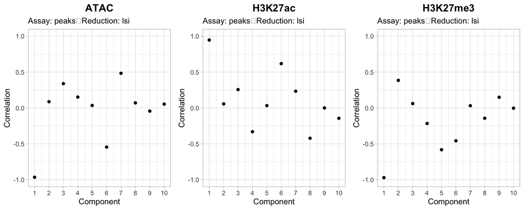

```r
plot.list <- lapply(combined.obj.ls,DepthCorMulMod)
ggarrange(plot.list[[1]],plot.list[[2]],plot.list[[3]],ncol=3)
```

Here, the correlation between the first LSI and sequencing depth is quite strong. We will discard it from further analyses.

## 5. Non-linear dimension reduction and clustering

Now that we have normalised and found variable features in the data, we can perform graph-based clustering and non-linear dimension reduction for visualization. This is done individually for each modality.

```r
# Run dimension reduction and clustering on each modality individually
combined.obj.ls <- lapply(combined.obj.ls,function(x){RunUMAP(x,reduction = 'lsi', dims = 2:40)})
combined.obj.ls <- lapply(combined.obj.ls,function(x){FindNeighbors(x,reduction = 'lsi', dims = 2:40)})
combined.obj.ls <- lapply(combined.obj.ls,function(x){FindClusters(x, verbose = FALSE, algorithm = 3)})
```

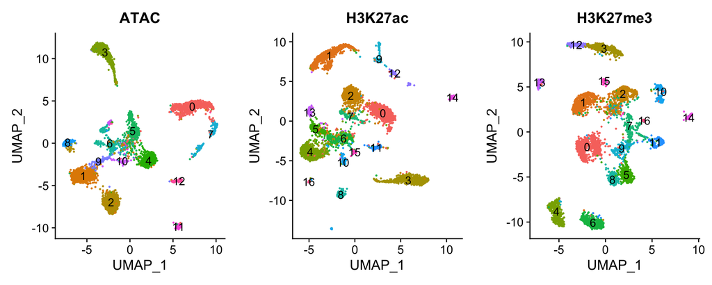

```r
# Plot each modality separately
p1=DimPlot(combined.obj.ls$ATAC, label = TRUE) + NoLegend() +
  ggtitle("ATAC") +
  theme(plot.title = element_text(size=15,hjust=0.5,face='bold'))

p2=DimPlot(combined.obj.ls$H3K27ac, label = TRUE) + NoLegend() +
  ggtitle("H3K27ac") +
  theme(plot.title = element_text(size=15,hjust=0.5,face='bold'))

p3=DimPlot(combined.obj.ls$H3K27me3, label = TRUE) + NoLegend() +
  ggtitle("H3K27me3") +
  theme(plot.title = element_text(size=15,hjust=0.5,face='bold'))

ggarrange(p1,p2,p3,ncol=3)
```